# 431 Class 06

Thomas E. Love, Ph.D.

2024-09-12

## Today’s Agenda

- Assumptions of our uncertainty intervals
  - for one sample / paired differences
  - for two independent samples
- Transforming an Outcome (see [Chapter 7 of our book](https://thomaselove.github.io/431-book/))
  - Why transform?
  - The importance of the logarithm and other power transformations
  - Tukey’s ladder and the Box-Cox plot
  - Back-transforming predictions, not coefficients

## Load packages and set theme

```r
library(janitor)

library(car)         ## new today
library(infer)       ## new today
library(MKinfer)

library(patchwork)
library(rstanarm)
library(easystats)
library(tidyverse)

theme_set(theme_bw())
knitr::opts_chunk$set(comment = NA)

source("c06/data/Love-431.R") # for the lovedist() function
```

## Returning to the DM-464 data

```r
dm6 <- read_csv("c06/data/dm464_class06.csv", show_col_types = FALSE) |>
  janitor::clean_names() |>
  mutate(across(where(is.character), as_factor)) |>
  mutate(statin_f = as_factor(statin),
         statin_f = fct_recode(statin_f,
                               "Statin" = "1", "No Statin" = "0")) |>
  mutate(id_code = as.character(id_code))

dim(dm6)
```

```
[1] 464   9
```

## Uncertainty Interval Assumptions

### One Sample (perhaps of Paired Differences)

- All approaches assume our sample is a **random** sample (or at least a representative one) from the population of interest.
- Ordinary Least Squares model / Paired T test also assumes that the population of interest follows a Normal distribution, so that our sample data should look as though it were drawn from a Normal distribution.
- Our Bayesian approach assumes a (weakly informative) prior distribution on the coefficient in our model.
- The bootstrap approach does not assume a Normal distribution for the population.

Main check in data: Normal distribution?

## Difference in A1c (end - baseline)

```r
dm6 <- dm6 |> mutate(a1c_diff = a1c_end - a1c_base)

p1 <- ggplot(dm6, aes(sample = a1c_diff)) +
  geom_qq() + geom_qq_line(col = "red") +
  labs(y = "A1c difference (%)", x = "Standard Normal Distribution",
    title = "Normal Q-Q plot")

bw = 1 # specify width of bins in histogram

p2 <- ggplot(dm6, aes(x = a1c_diff)) +
  geom_histogram(binwidth = bw, fill = "black", col = "yellow") +
  stat_function(fun = function(x)
    dnorm(x, mean = mean(dm6$a1c_diff, na.rm = TRUE),
          sd = sd(dm6$a1c_diff, na.rm = TRUE)) *
          length(dm6$a1c_diff) * bw,
    geom = "area", alpha = 0.5,
    fill = "lightblue", col = "blue") +
  labs(x = "A1c difference (%)", y = "Count",
       title = "Histogram & Normal Curve")

p1 + p2 +
  plot_annotation("Are differences in Hemoglobin A1c Normally distributed?")
```

## Difference in A1c (end - baseline)

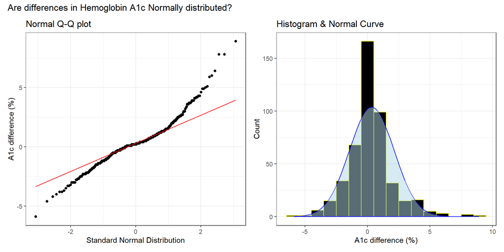

## Boxplot for Difference in A1c

```r
ggplot(dm6, aes(x = a1c_diff, y = "")) +
  geom_violin(fill = "cornsilk") +
  geom_boxplot(width = 0.2) +
  stat_summary(fun = mean, geom = "point", shape = 16, col = "red") +
  labs(y = "", x = "A1c difference (%)", title = "Boxplot with Violin")
```

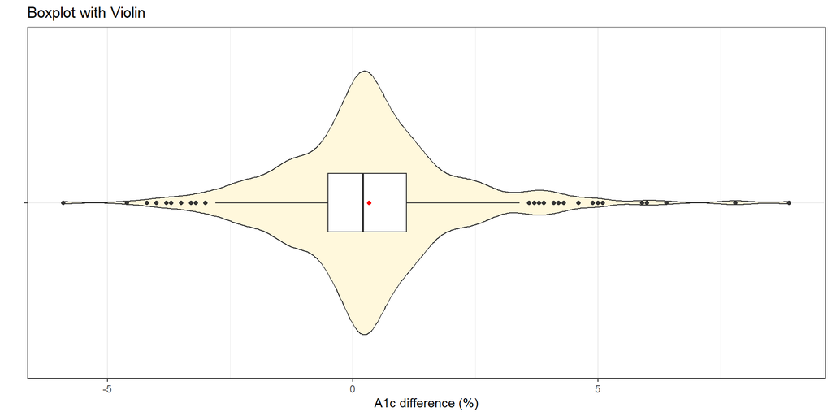

## Does a Normal model fit well?

Do we have …

1. A histogram that is symmetric and bell-shaped.
2. A boxplot where the box is symmetric around the median, as are the whiskers, without severe outliers.
3. A normal Q-Q plot that essentially falls on a straight line.
4. If in doubt, maybe compare mean and sd to median and MAD, and consider Empirical Rule to help make tough calls.
- **Don’t** rely on hypothesis tests of whether data follow a Normal distribution.

## What to do about outliers?

The paired differences here appear to be symmetric, but with outliers.

- This should push us towards a method which doesn’t require the assumption of Normality.
  - Specifically, the bootstrap would likely be a better choice than a t test, although it didn’t make a meaningful difference when we ran it last time.
  - 90% uncertainty interval with OLS/t test was (0.20, 0.47) and the bootstrap 90% uncertainty interval was also (0.20, 0.47).
- Could we transform these data in a non-linear way to better match assumptions?
  - Not really, no. Most of the transformations we use regularly are designed to address skew in the data, rather than tail behavior.
- Should we build our interval around the median instead of the mean?
  - sample median = 0.2, sample mean = 0.33
  - Maybe, but does that actually address the issue in this case?

## Bootstrap 90% interval for Median

This is from the `infer` package…

```r
set.seed(431)

x_med <- dm6 |> observe(response = a1c_diff, stat = "median")

res1 <- dm6 |>
  specify(response = a1c_diff) |>
  generate(reps = 2000, type = "bootstrap") |>
  calculate(stat = "median") |>
  get_confidence_interval(level = 0.90, type = "percentile")

res1 <- res1 |> mutate(pt_est = x_med$stat) |>
  relocate(pt_est)

res1
```

```
# A tibble: 1 × 3
  pt_est lower_ci upper_ci
   <dbl>    <dbl>    <dbl>
1  0.200    0.200    0.300
```

## A Strategy for Paired Samples

Suppose we want to estimate an uncertainty interval for the mean of a set of paired differences.

- Calculate the paired differences, then plot them.
- If the sample data are well described as “Normal”, then use the OLS / paired t procedure to obtain a confidence interval, or a Bayesian model to obtain a credible interval.
- If the sample data are best described as “symmetric but with outliers”, then use the bootstrap to obtain a confidence interval, although an OLS or Bayesian result may be quite similar.
- If the sample data are best described as “substantially skewed”, then consider whether you actually want to summarize with the mean, and consider whether a transformation might be helpful.

## Uncertainty Interval Assumptions

### Two Independent Samples

- All methods assume each of the two samples is a random sample (or at least a representative one) from its population of interest.
- Ordinary Least Squares model / Pooled T test additionally assumes that:
  - **each** of the two populations of interest follows a Normal distribution, **and**
  - **either** the variance of those two populations is equal, so it makes sense to create a pooled estimate of the standard deviation, **or** the sample sizes are equal in the two groups (a balanced design)
- The Welch t test assumes Normality, but not equal variances.
- Our Bayesian approach assumes a (weakly informative) prior distribution on each of the coefficients (intercept and slope) of our model.
- The bootstrap approach does not assume a Normal distribution for the population, but can take advantage of an assumption of equal variances if it exists.

## From last class…

Estimating the mean difference in LDL levels at baseline for the “Statin” group minus the “No Statin” group…

| Approach | Estimate & 90% Interval |
| --- | --- |
| Ordinary least squares / Pooled t | 7.17 (0.02, 14.32) |
| Bayesian fit with `stan_glm()` | 7.22 (-0.06, 14.56) |
| Welch t without pooling sd | 7.17 (0.86, 13.48) |
| Bootstrap with pooled sd | 7.21 (0.34, 14.29) |
| Bootstrap with unpooled sd | 7.23 (0.88, 13.66) |

- Is there a big impact here of using the Bootstrap rather than OLS?

## LDL by Statin prescription status

```r
ggplot(dm6, aes(x = ldl_base, y = statin_f)) +
  geom_violin() +
  geom_boxplot(aes(fill = statin_f), width = 0.3) +
  stat_summary(fun = mean, geom = "point",
               shape = 18, size = 3, col = "yellow") +
  guides(fill = "none") +
  labs(y = "Statin prescription", x = "LDL Cholesterol (mg/dl)",
       title = "LDL by Statin prescription",
       subtitle = "Each group is a bit skewed to the right")
```

## LDL by Statin prescription status

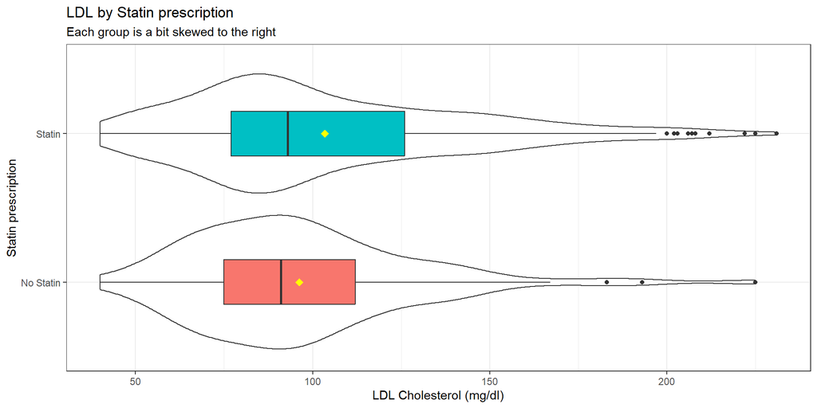

## Can we do something about the skew?

- Could we build a confidence interval for medians instead of means?
  - Yes, with the bootstrap, for example.
- Could we transform the data in a non-linear way to better match assumptions?
  - Yes, with the help of Tukey’s ladder of power transformations.

## Tukey’s Ladder

| Power ($\lambda$) | -2 | -1 | -0.5 | 0 | 0.5 | 1 | 2 | 3 |
| --- | --- | --- | --- | --- | --- | --- | --- | --- |
| Transformation | $\frac{1}{y^2}$ | $\frac{1}{y}$ | $\frac{1}{\sqrt{y}}$ | log $y$ | $\sqrt{y}$ | $y$ | $y^2$ | $y^3$ |

- Works to address skew, mainly, rather than symmetry with problems in the tails
- Some of these transformations require all values to be positive. If they aren’t, we can add a small amount to each observation until they are.
- Start at no transformation ($\lambda = 1$)
- Try moving in one direction or the other, searching for a result which better matches what we might expect from a Normal distribution
  - If a step (like taking the square root) helps, move in that same direction.
  - If it doesn’t help, try moving in the other direction.

## A1c values (end of study)

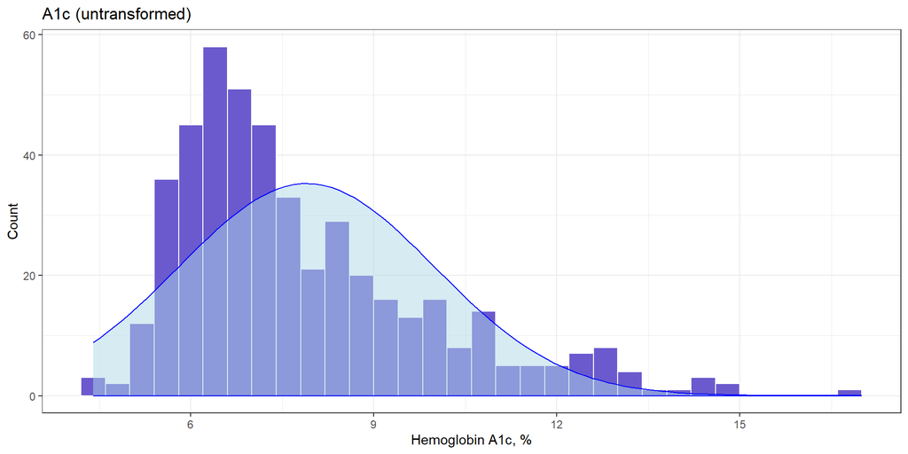

## Six Power Transformations

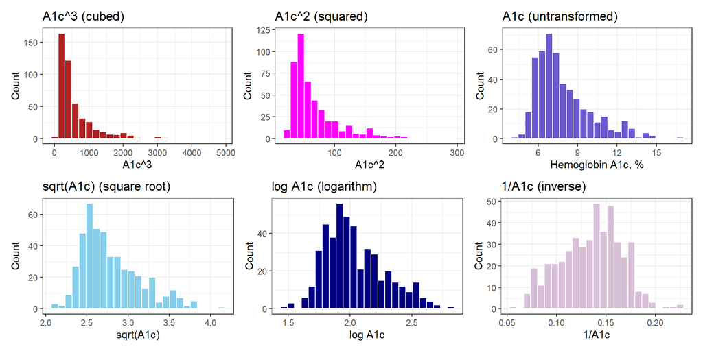

## Which Transformation to Choose?

Box-Cox approach: can we get a suggested “power” to use when transforming our outcome?

- Specify the model then apply `boxCox` from `car` package.
- Here, all values of our outcome (A1c) are strictly positive.
  - If not, we’d have to add a constant so that they were.

```r
fit1 <- lm(a1c_end ~ 1, data = dm6)
boxCox(fit1)
```

## Which Transformation to Choose?

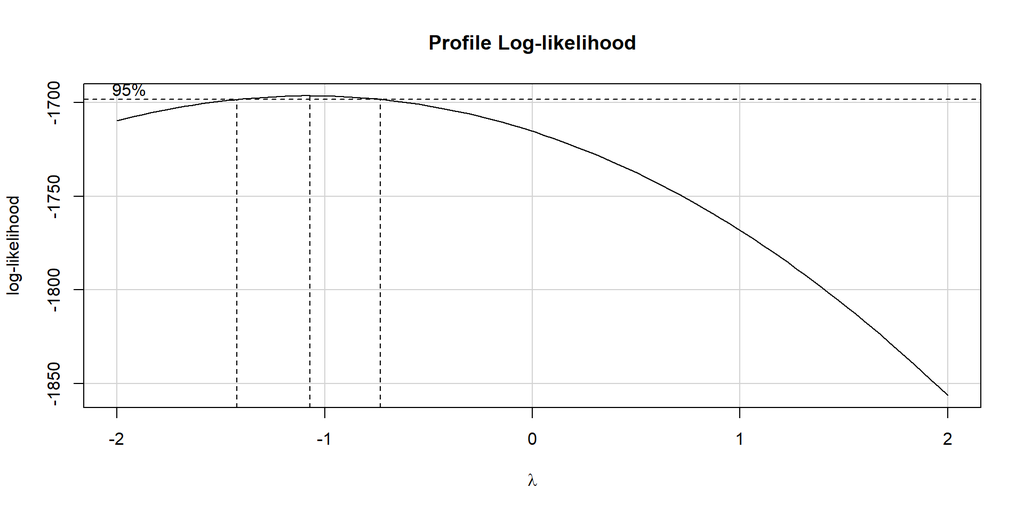

## Back to LDL by Statin prescription

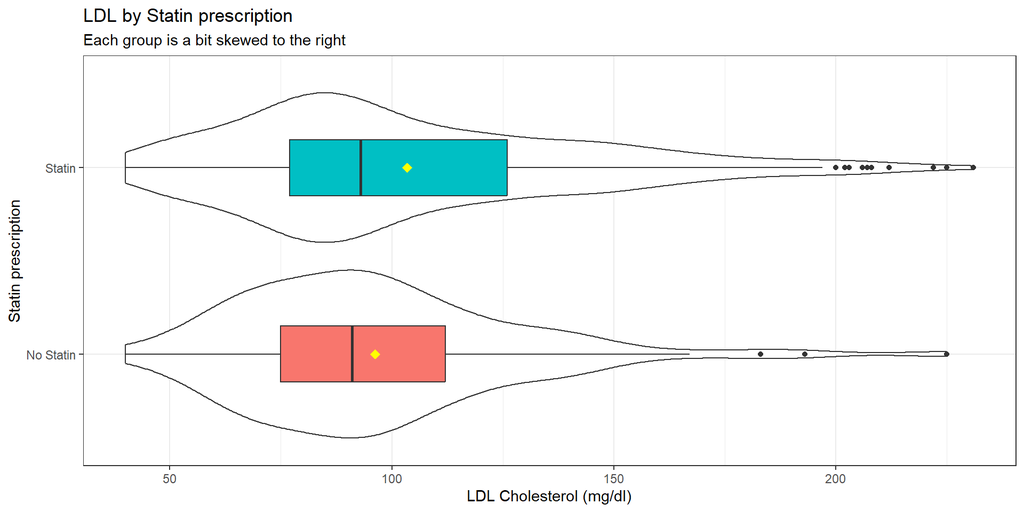

## What transformation should we try?

```r
fit2 <- lm(ldl_base ~ statin, data = dm6)
boxCox(fit2)
```

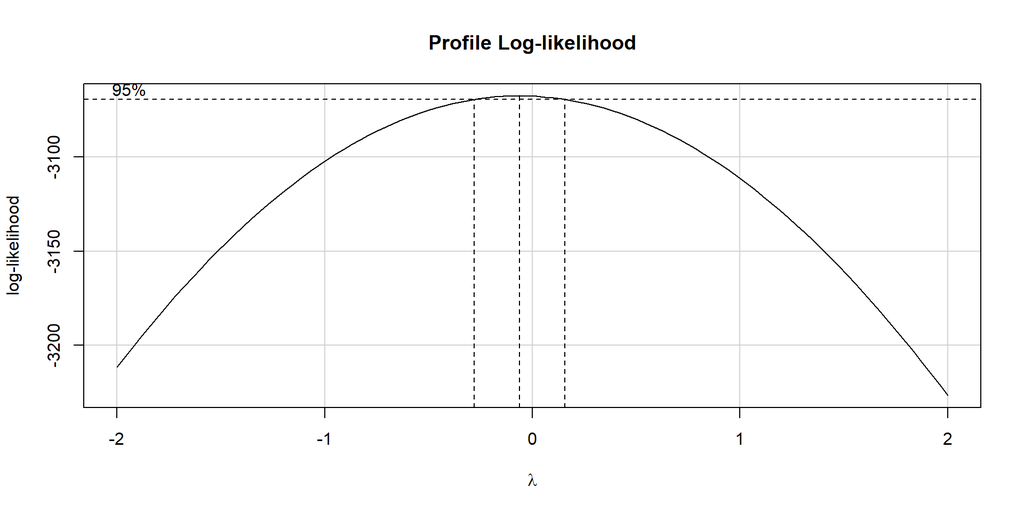

## log(LDL) by Statin?

```r
ggplot(dm6, aes(x = log(ldl_base), y = statin_f)) +
  geom_violin() + geom_boxplot(aes(fill = statin_f), width = 0.3) +
  labs(y = "Statin prescription", x = "log(LDL)",
       title = "log(LDL) by Statin prescription") +
  guides(fill = "none")
```

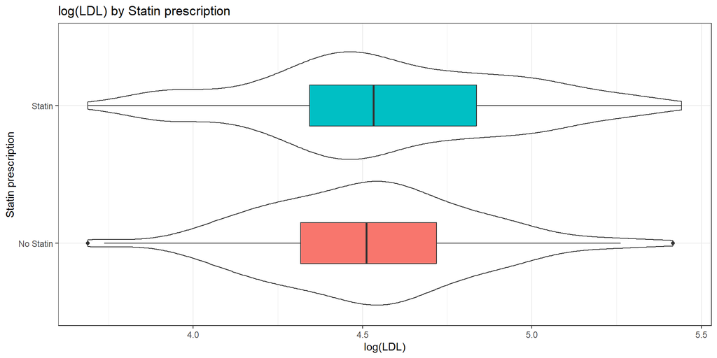

## Estimate log(LDL) by Statin

Let’s use a 90% uncertainty interval…

```r
fit3 <- lm(log(ldl_base) ~ statin_f, data = dm6)

model_parameters(fit3, ci = 0.90)
```

```
Parameter         | Coefficient |   SE |        90% CI | t(462) |      p
------------------------------------------------------------------------
(Intercept)       |        4.52 | 0.04 | [ 4.46, 4.58] | 122.75 | < .001
statin f [Statin] |        0.05 | 0.04 | [-0.02, 0.12] |   1.23 | 0.220
```

```
Uncertainty intervals (equal-tailed) and p-values (two-tailed) computed
  using a Wald t-distribution approximation.
```

```
The model has a log-transformed response variable. Consider using
  `exponentiate = TRUE` to interpret coefficients as ratios.
```

## Expectations from our model

- The coefficients of this model exist in the transformed world, but we can make predictions back on our original scale.

```r
estimate_expectation(fit3, data = "grid", ci = 0.90)
```

```
Model-based Expectation

statin_f  | Predicted |   SE |       90% CI
-------------------------------------------
No Statin |      4.52 | 0.04 | [4.46, 4.58]
Statin    |      4.57 | 0.02 | [4.54, 4.60]

Variable predicted: ldl_base
Predictors modulated: statin_f
```

- and we exponentiate to get back to our original scale…

## Exponentiation of Expectations

- We back out of the logged predictions by exponentiating them.

| Group | Predicted LDL | 90% uncertainty interval |
| --- | --- | --- |
| No Statin | exp(4.52) = 91.8 | (exp(4.46), exp(4.58)) = (86.5, 97.5) |
| Statin | exp(4.57) = 96.5 | (exp(4.54), exp(4.60)) = (93.7, 99.5) |

- These intervals describe uncertainty about the **average predicted LDL across all subjects** in each statin group.

## Fitting Individual Predictions

- We use `estimate_prediction()` to make predictions for an individual subject in each group.

```r
estimate_prediction(fit3, data = "grid", ci = 0.90)
```

```
Model-based Prediction

statin_f  | Predicted |   SE |       90% CI
-------------------------------------------
No Statin |      4.52 | 0.36 | [3.92, 5.12]
Statin    |      4.57 | 0.36 | [3.97, 5.17]

Variable predicted: ldl_base
Predictors modulated: statin_f
```

- and again we exponentiate to get back to our original scale…

## Fitting Individual Predictions

- We back out of the logged predictions by exponentiating them.

| Group | Predicted LDL | 90% uncertainty interval |
| --- | --- | --- |
| No Statin | exp(4.52) = 91.8 | (exp(3.92), exp(5.12)) = (50.4, 167.3) |
| Statin | exp(4.57) = 96.5 | (exp(3.97), exp(5.17)) = (53, 175.9) |

- These intervals describe uncertainty about an **individual predicted LDL for a single subject** within each statin group.

## Using the log transformation

- The log transformation in R (`log` in R is the natural log - the base 10 log is `log10()`) generates coefficients which describe a multiplicative effect.

If we fit a model to predict $y$ using $x$ of the form:

$$\log y = \beta_0 + \beta_1 x$$

where $\log y$ is the natural logarithm, then if we exponentiate the slope coefficient, we get the multiplicative factor for each one-unit increase in the predictor.

## The Math

$$\log(y) = \beta_0 + \beta_1 x \\
\exp(\log(y)) = \exp(\beta_0 + \beta_1 x) \\
y = \exp(\beta_0 + \beta_1 x) \\
y = \exp(\beta_0) \times \exp(\beta_1 x)$$
This implies that our predictor ($x$) has a multiplicative relationship with our outcome ($y$) instead of the usual additive relationship. Hence, we can express the effect of a one-unit change in $x$ on $y$ as a percentage change.

## Example 1

Suppose we build a regression model with equation $\log y = 6 + 0.23 x$.

Note that $\exp(0.23) = 1.26$.

- If Harry’s value of $x$ is 1 point larger than Sally’s, the predicted $y$ value for Harry will be increased by 26% relative to Sally’s. (Increased by 26% = multiplied by 1.26.)

## Example 2

```r
fit3 <- lm(log(ldl_base) ~ statin_f, data = dm6)

model_parameters(fit3, ci = 0.90)
```

```
Parameter         | Coefficient |   SE |        90% CI | t(462) |      p
------------------------------------------------------------------------
(Intercept)       |        4.52 | 0.04 | [ 4.46, 4.58] | 122.75 | < .001
statin f [Statin] |        0.05 | 0.04 | [-0.02, 0.12] |   1.23 | 0.220
```

- We can exponentiate these coefficients…

```
Parameter         | Coefficient |   SE |         90% CI | t(462) |      p
-------------------------------------------------------------------------
(Intercept)       |       91.67 | 3.37 | [86.27, 97.40] | 122.75 | < .001
statin f [Statin] |        1.05 | 0.04 | [ 0.98,  1.13] |   1.23 | 0.220
```

Subjects *with* a statin prescription have 5% higher LDL, on average, than do subjects *without*. The ratio has point estimate 1.05 and 90% interval estimate (0.98, 1.13).

## A Strategy for Independent Samples

Suppose we want to estimate an uncertainty interval for the difference in means across two groups. To begin, plot the data from each sample.

- If the sample data in each group are well described as “Normal”, then use the OLS / pooled t procedure to obtain a confidence interval, or a Bayesian model to obtain a credible interval.
  - If the sample sizes are not the same, and the sample variances aren’t close to each other, consider using a Welch t procedure.
- If either sample’s data are “symmetric but with outliers”, then consider using the bootstrap to obtain a confidence interval, although an OLS or Bayesian result may also be reasonable.
- If either sample’s data are best described as “substantially skewed”, then consider whether you actually want to summarize with the difference in means, and consider whether a transformation might be helpful.

## Difference in A1c by Sex

```r
ggplot(dm6, aes(x = a1c_diff, y = sex)) +
  geom_violin() + geom_boxplot(aes(fill = sex), width = 0.3) +
  labs(x = "Change in A1c", y = "Sex",
       title = "Difference in A1c (end - base) by Sex") +
  guides(fill = "none")
```

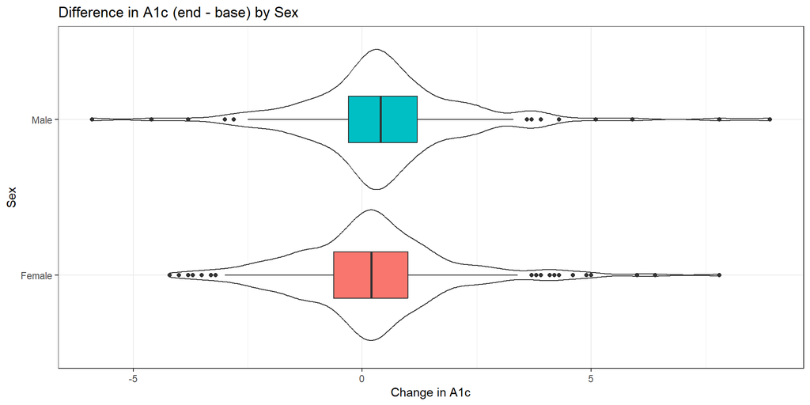

## Numerical Summary

```r
dm6 |> group_by(sex) |>
  reframe(lovedist(a1c_diff)) |>
  print_md(digits = 3)
```

| sex | n | miss | mean | sd | med | mad | min | q25 | q75 | max |
| --- | --- | --- | --- | --- | --- | --- | --- | --- | --- | --- |
| Female | 288 | 0 | 0.227 | 1.747 | 0.200 | 1.186 | -4.200 | -0.625 | 1.000 | 7.800 |
| Male | 176 | 0 | 0.503 | 1.838 | 0.400 | 1.186 | -5.900 | -0.300 | 1.200 | 8.900 |

- Observed difference in sample means is 0.503 - 0.227 = 0.276
- Do we have a balanced design?
- Do we feel comfortable pooling these standard deviations?
- Do we feel comfortable assuming Normality for each sex?

## Might a transformation help here?

Some of the changes in A1c are negative (minimum was -5.9)

```r
dm6 <- dm6 |> mutate(a1c_diff_p6 = a1c_diff + 6)
fit4 <- lm(a1c_diff_p6 ~ sex, data = dm6)
boxCox(fit4)
```

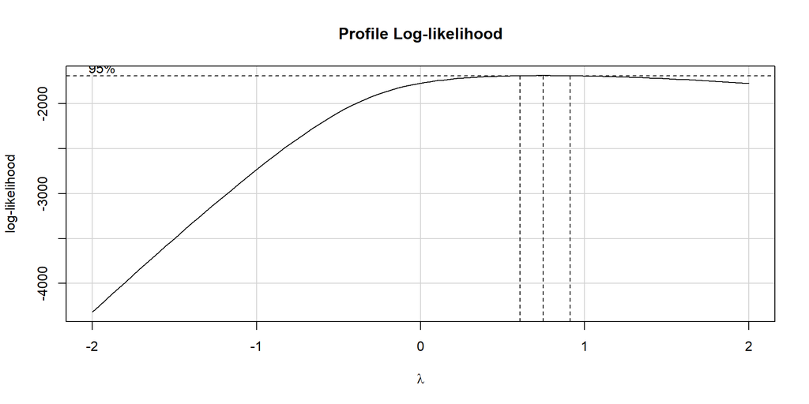

## Does using a square root help us here?

```r
p1 <- ggplot(dm6, aes(x = a1c_diff_p6, y = sex)) +
  geom_violin() + geom_boxplot(aes(fill = sex), width = 0.3) +
  labs(x = "Change in A1c + 6", y = "Sex",
       title = "A1c difference (+ 6) by Sex") +
  guides(fill = "none")

p2 <- ggplot(dm6, aes(x = sqrt(a1c_diff_p6), y = sex)) +
  geom_violin() + geom_boxplot(aes(fill = sex), width = 0.3) +
  labs(x = "Square Root of (Change in A1c + 6)", y = "Sex",
       title = "Square Root of (A1c difference + 6) by Sex") +
  guides(fill = "none")

p1 / p2
```

## Does using a square root help us here?

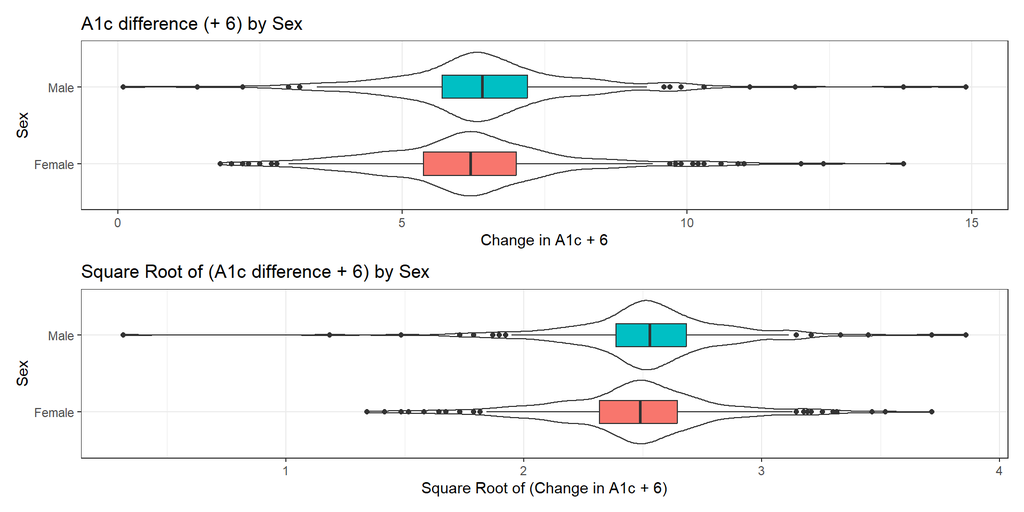

## Addressing outliers?

### OLS model

```r
fit5 <- lm(a1c_diff ~ sex, data = dm6)

model_parameters(fit5, ci = 0.90)
```

```
Parameter   | Coefficient |   SE |        90% CI | t(462) |     p
-----------------------------------------------------------------
(Intercept) |        0.23 | 0.11 | [ 0.05, 0.40] |   2.16 | 0.031
sex [Male]  |        0.28 | 0.17 | [ 0.00, 0.56] |   1.62 | 0.105
```

- Male subjects had A1c changes that were 0.28 larger than females, on average, with 90% uncertainty interval (0, 0.56) according to our OLS model (pooled t test.)

## Addressing outliers?

### Bayesian model

```r
set.seed(20240912)
fit6 <- stan_glm(a1c_diff ~ sex, data = dm6, refresh = 0)

model_parameters(fit6, ci = 0.90)
```

```
Parameter   | Median |        90% CI |     pd |  Rhat |     ESS |                 Prior
---------------------------------------------------------------------------------------
(Intercept) |   0.22 | [ 0.05, 0.39] | 98.42% | 1.000 | 3666.00 | Normal (0.33 +- 4.46)
sexMale     |   0.28 | [ 0.00, 0.57] | 94.80% | 1.000 | 3649.00 | Normal (0.00 +- 9.19)
```

- Male subjects had A1c changes that were 0.28 larger than females, on average, with 90% uncertainty interval (0, 0.57) according to our Bayesian model.

## Addressing outliers?

### Bootstrap with `boot.t.test`

```r
set.seed(20240912)
boot.t.test(a1c_diff ~ sex, data = dm6, conf.level = 0.90)
```

```
    Bootstrap Welch Two Sample t-test

data:  a1c_diff by sex
number of bootstrap samples:  9999
bootstrap p-value = 0.1096
bootstrap difference of means (SE) = -0.2787276 (0.1715815)
90 percent bootstrap percentile confidence interval:
 -0.566107955  0.002070707

Results without bootstrap:
t = -1.6028, df = 355.56, p-value = 0.1099
alternative hypothesis: true difference in means is not equal to 0
90 percent confidence interval:
 -0.561349458  0.008003498
sample estimates:
mean in group Female   mean in group Male
           0.2267361            0.5034091
```

## Repeating: Paired Samples Strategy

Suppose we want to estimate an uncertainty interval for the mean of a set of paired differences.

- Calculate the paired differences, then plot them.
- If the sample data are well described as “Normal”, then use the OLS / paired t procedure to obtain a confidence interval, or a Bayesian model to obtain a credible interval.
- If the sample data are best described as “symmetric but with outliers”, then use the bootstrap to obtain a confidence interval, although an OLS or Bayesian result may be quite similar.
- If the sample data are best described as “substantially skewed”, then consider whether you actually want to summarize with the mean, and consider whether a transformation might be helpful.

## Independent Samples Strategy

Suppose we want to estimate an uncertainty interval for the difference in means across two groups. To begin, plot the data from each sample.

- If the sample data in each group are well described as “Normal”, then use the OLS / pooled t procedure to obtain a confidence interval, or a Bayesian model to obtain a credible interval.
  - If the sample sizes are not the same, and the sample variances aren’t close to each other, consider using a Welch t procedure.
- If either sample’s data are “symmetric but with outliers”, then consider using the bootstrap to obtain a confidence interval, although an OLS or Bayesian result may also be reasonable.
- If either sample’s data are best described as “substantially skewed”, then consider whether you actually want to summarize with the difference in means, and consider whether a transformation might be helpful.

431 Class 06 | 2024-09-12 | https://thomaselove.github.io/431-2024/